-

# Plan de travail

1. Introduction
2. Chargement et préparation des données
3. Analyse exploratoire : Analyse univariée, bivariée, réduction de dimension
4. Application d’un modèle de régression
5. Application d’un modèle de classification (clustering)
6. Conclusion, synthèse de l’analyse

## 1. Introduction

Ce document présente une analyse exploratoire des données de l’enquête sur la participation électorale de 2017 par département (96 départements). Les données 2014 et 2015 sont diffusées selon la géographie en vigueur au 1er janvier 2016.

### Description des variables

- Department : nom du département
- Code : numéro du département
- HLM : pourcentage du nombre de locataires HLM
- Salairemoy : moyenne du salaire horaire net
- Ouvrier : pourcentage d’ouvriers présents par rapport aux emplois disponibles
- Employé : pourcentage d’employés présents par apport aux emplois disponibles
- PI : pourcentage de professions intermédiaires par rapport aux emplois disponibles
- Cadres : pourcentage de cadre par apport aux emplois disponibles
- Artisan : pourcentage du nombres d’artisans par apportaux em plois disponibles
- Agri : pourcentage du nombres d’agriculteurs par apport aux emplois disponibles
- TxPauv : taux de pauvreté en 2014
- NonDiplome : pourcentage de personnes non scolarisées de 15 ans ou des non ou peu diplômés
- txcho : taux de chomâge au 2ème trimestre 2017
- txabs : taux d’abstention aux éléctions présidentielles de 2017

## 2. Chargement et préparation des données

```r
library(ggplot2)
library(dplyr)
library(factoextra)
library(compositions)
library(corrplot)
library(FactoMineR)
```

Nous commençons par charger les données pour explorer leur structure et leur contenu.

```r
df <- read.csv("data/data_abs.csv", header = TRUE, sep = ",")
df
```

```
##     X              Department Code  HLM Salairemoy Ouvrier Employe   PI Cadres
## 1   1                     Ain    1 14.4      13.58    27.4    26.3 25.3   11.8
## 2   2                   Aisne    2 16.0      12.52    28.6    30.5 22.6    9.6
## 3   3                  Allier    3 10.8      12.10    24.7    32.2 22.3    9.2
## 4   4 Alpes-de-Haute-Provence    4  7.6      12.73    19.6    30.0 25.7   10.7
## 5   5            Hautes-Alpes    5 11.3      12.04    18.9    32.4 26.6    9.4
## 6   6         Alpes-Maritimes    6  8.8      14.22    15.5    31.1 25.2   17.6
## 7   7                 Ardèche    7  7.5      12.65    23.4    28.4 24.0   10.5
## 8   8                Ardennes    8 18.0      12.60    29.2    29.3 22.7    9.7
## 9   9                  Ariège    9  4.5      12.15    20.6    31.4 24.8    9.6
## 10 10                    Aube   10 19.6      12.41    26.6    29.0 23.7   10.6
## 11 11                    Aude   11  8.2      11.91    20.0    31.2 24.1   10.5
## 12 12                 Aveyron   12  5.9      12.01    22.7    27.4 22.8    9.0
## 13 13        Bouches-du-Rhône   13 15.5      14.40    16.9    28.6 27.8   19.3
## 14 14                Calvados   14 16.9      12.80    23.4    29.8 24.9   13.0
```

[output cut: 179 more lines]

Nous avons 15 colonnes et 96 observations (cela correspond au 96 départements).

```r
str(df)
```

```
## 'data.frame':    96 obs. of  15 variables:
##  $ X         : int  1 2 3 4 5 6 7 8 9 10 ...
##  $ Department: chr  "Ain" "Aisne" "Allier" "Alpes-de-Haute-Provence" ...
##  $ Code      : chr  "1" "2" "3" "4" ...
##  $ HLM       : num  14.4 16 10.8 7.6 11.3 8.8 7.5 18 4.5 19.6 ...
##  $ Salairemoy: num  13.6 12.5 12.1 12.7 12 ...
##  $ Ouvrier   : num  27.4 28.6 24.7 19.6 18.9 15.5 23.4 29.2 20.6 26.6 ...
##  $ Employe   : num  26.3 30.5 32.2 30 32.4 31.1 28.4 29.3 31.4 29 ...
##  $ PI        : num  25.3 22.6 22.3 25.7 26.6 25.2 24 22.7 24.8 23.7 ...
##  $ Cadres    : num  11.8 9.6 9.2 10.7 9.4 17.6 10.5 9.7 9.6 10.6 ...
##  $ Artisant  : num  7.5 6.1 7.4 10.4 9.8 10.2 10.1 6.2 9.5 6.3 ...
##  $ Agri      : num  1.7 2.6 4.3 3.6 2.9 0.4 3.6 3 4.1 3.8 ...
##  $ TxPauv    : num  10.8 18.7 15.4 17 14.5 16 14.7 19.4 18.2 15.6 ...
##  $ NonDiplome: num  29.4 39.9 36.4 31.3 28.4 31.6 33.8 39.1 33.6 38.1 ...
##  $ txcho     : num  6.8 13.1 9.9 11.1 8.7 10 10.2 11.2 11.6 12 ...
##  $ txabs     : num  19.6 21.3 21.4 19.2 18.9 21.3 18.7 22.7 18.2 19.1 ...
```

Nos colonnes sont du bon type. On peut voir que nous avons principalement des données numériques.

```r
colSums(is.na(df))
```

```
##          X Department       Code        HLM Salairemoy    Ouvrier    Employe
##          0          0          0          0          0          0          0
##         PI     Cadres   Artisant       Agri     TxPauv NonDiplome      txcho
##          0          0          0          0          0          0          0
##      txabs
##          0
```

Nous n’avons pas de valeurs manquantes dans le dataset.

## 3. Analyse exploratoire

### Analyse univariée

#### Statistiques descriptives

```r
summary(df)
```

```
##        X          Department            Code                HLM
##  Min.   : 1.00   Length:96          Length:96          Min.   : 4.50
##  1st Qu.:24.75   Class :character   Class :character   1st Qu.: 8.75
##  Median :48.50   Mode  :character   Mode  :character   Median :11.90
##  Mean   :48.50                                         Mean   :12.68
##  3rd Qu.:72.25                                         3rd Qu.:15.32
##  Max.   :96.00                                         Max.   :32.40
##    Salairemoy       Ouvrier         Employe            PI
##  Min.   :11.29   Min.   : 8.10   Min.   :20.50   Min.   :20.70
##  1st Qu.:12.29   1st Qu.:20.15   1st Qu.:27.85   1st Qu.:23.38
##  Median :12.71   Median :23.05   Median :28.90   Median :24.80
##  Mean   :13.24   Mean   :22.85   Mean   :28.89   Mean   :24.80
##  3rd Qu.:13.59   3rd Qu.:26.45   3rd Qu.:30.35   3rd Qu.:26.43
##  Max.   :22.16   Max.   :30.80   Max.   :34.10   Max.   :28.90
##      Cadres         Artisant           Agri            TxPauv
##  Min.   : 8.20   Min.   : 3.800   Min.   : 0.000   Min.   : 9.40
##  1st Qu.: 9.80   1st Qu.: 5.900   1st Qu.: 1.200   1st Qu.:12.50
##  Median :11.30   Median : 7.100   Median : 2.600   Median :14.40
##  Mean   :13.32   Mean   : 7.317   Mean   : 2.826   Mean   :14.67
##  3rd Qu.:14.72   3rd Qu.: 8.800   3rd Qu.: 3.850   3rd Qu.:15.93
##  Max.   :42.20   Max.   :11.600   Max.   :10.600   Max.   :28.60
##    NonDiplome        txcho            txabs
##  Min.   :19.70   Min.   : 5.700   Min.   :15.70
##  1st Qu.:30.25   1st Qu.: 7.900   1st Qu.:18.50
##  Median :33.25   Median : 8.950   Median :19.80
##  Mean   :32.67   Mean   : 9.132   Mean   :19.92
##  3rd Qu.:35.38   3rd Qu.:10.000   3rd Qu.:21.30
##  Max.   :40.20   Max.   :14.400   Max.   :32.80
```

Les statistiques montrent des différences importantes entre les départements en termes de conditions socio-économiques. Par exemple, la part des locataires HLM va de 4,5 % à 32,4 %, ce qui reflète des écarts entre les zones urbaines et rurales. Le salaire moyen varie aussi beaucoup, entre 11,29 € et 22,16 €, montrant des inégalités de revenus. Les professions sont également différentes selon les départements : les ouvriers et employés représentent la majorité des emplois (environ 23 % et 29 % en moyenne), tandis que les cadres sont moins nombreux, avec une moyenne de 13 % mais atteignent jusqu’à 42 % dans certains endroits.

Le taux de pauvreté varie entre 9,4 % et 28,6 %, et la proportion de personnes peu ou pas diplômées va de 19,7 % à 40,2 %. Le chômage est aussi inégal, entre 5,7 % et 14,4 %. Enfin, le taux d’abstention est en moyenne de 19,92 %, mais peut aller jusqu’à 32,8 %.

Ces différences montrent que certains départements, avec un taux de pauvreté, de chômage, ou de non-diplômés plus élevé, pourraient avoir des taux d’abstention plus importants. La régression aidera à trouver les facteurs qui influencent le plus l’abstention, et le clustering permettra de regrouper les départements en fonction de leurs profils pour mieux comprendre leurs dynamiques.

#### Boîtes à moustaches des variables numériques

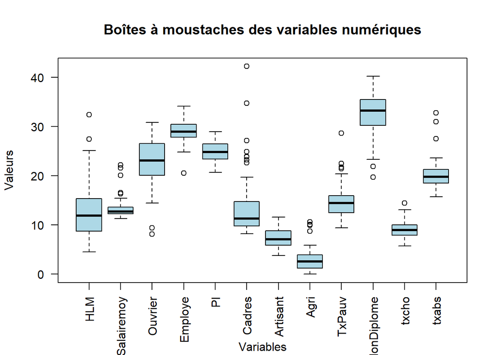

```r
numeric_vars <- c("HLM", "Salairemoy", "Ouvrier", "Employe", "PI",
                  "Cadres", "Artisant", "Agri", "TxPauv", "NonDiplome", "txcho", "txabs")
df_numeric <- df[, numeric_vars]
df_long <- stack(df_numeric)
boxplot(values ~ ind, data = df_long,
        main = "Boîtes à moustaches des variables numériques",
        xlab = "", ylab = "Valeurs", las = 2, col = "lightblue",
        outline = TRUE)
mtext("Variables", side = 1, line = 4)
```

La proportion de locataires HLM, le taux de pauvreté et le pourcentage de personnes non diplômées varient beaucoup, avec certains départements qui se démarquent (outliers). On observe aussi que les catégories professionnelles (comme les cadres ou les agriculteurs) ne sont pas réparties de manière égale, tout comme les salaires. Le taux d’abstention est assez homogène autour de 20 %, il est plus élevé dans certains départements, ce qui pourrait refléter des contextes socio-économiques spécifiques.

#### Histogrammes des variables continues

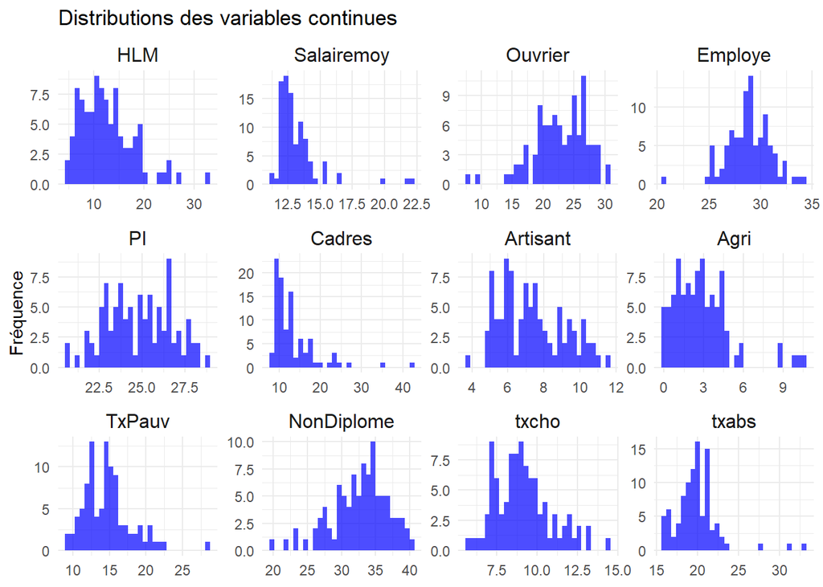

```r
library(ggplot2)
ggplot(df_long, aes(x = values)) +
  geom_histogram(bins = 30, fill = "blue", alpha = 0.7) +
  facet_wrap(~ind, scales = "free") +
  theme_minimal() +
  labs(title = "Distributions des variables continues", y = "Fréquence") +
  theme(axis.title.x = element_blank()) +
  theme(strip.text = element_text(size = 12))
```

### Analyse bivariée

#### Corrélation des variables numériques

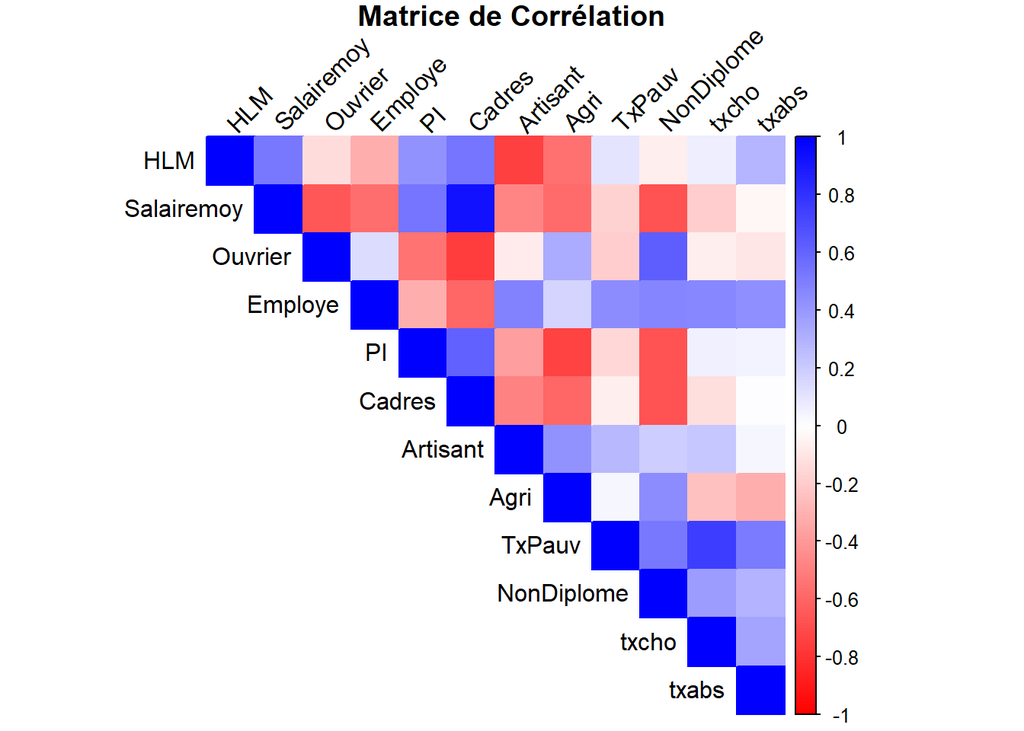

```r
library(corrplot)

if(!require(corrplot)) install.packages("corrplot")
cor_matrix <- stats::cor(df_numeric, use = "complete.obs")
corrplot(cor_matrix, method = "color", type = "upper", tl.col = "black", tl.srt = 45,
         col = colorRampPalette(c("red", "white", "blue"))(200),
         title = "Matrice de Corrélation", mar = c(0, 0, 1, 0))
```

#### Relation entre le taux d’abstention et d’autres variables

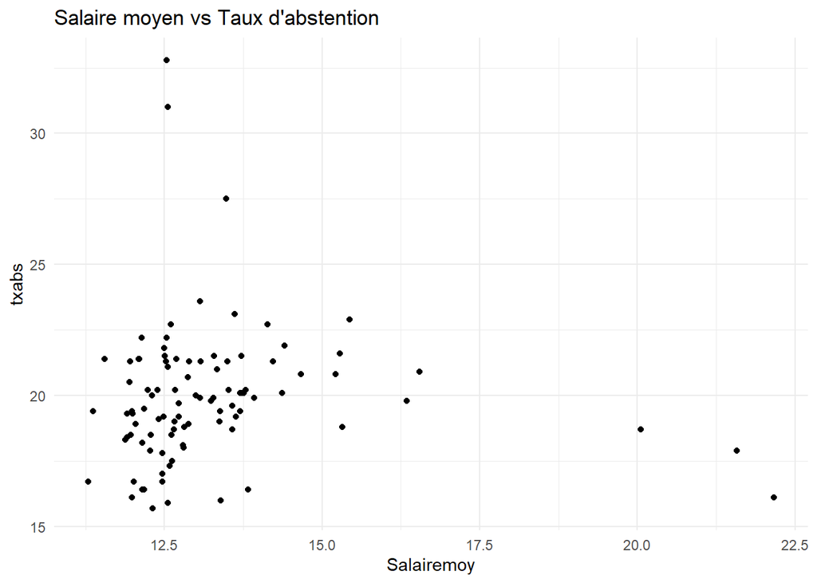

```r
ggplot(df, aes(x = Salairemoy, y = txabs)) +
  geom_point() +
  theme_minimal() +
  labs(title = "Salaire moyen vs Taux d'abstention")
```

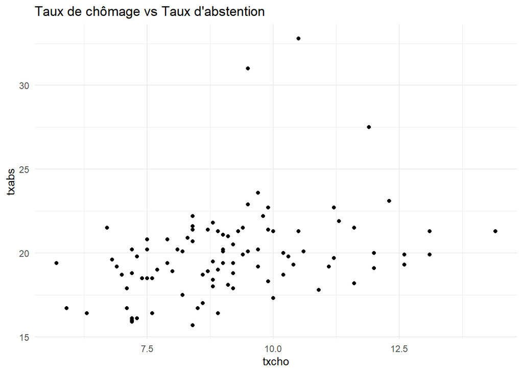

```r
ggplot(df, aes(x = txcho, y = txabs)) +
  geom_point() +
  theme_minimal() +
  labs(title = "Taux de chômage vs Taux d'abstention")
```

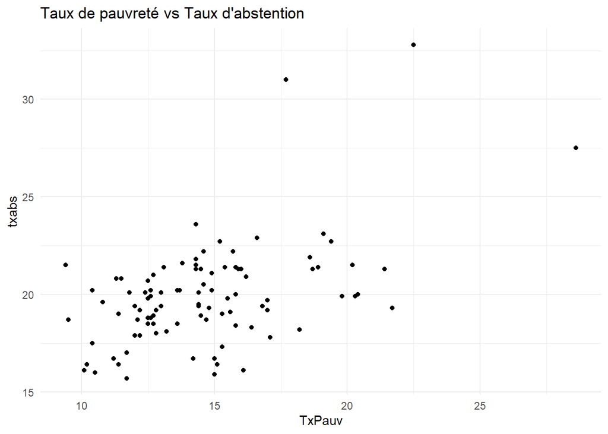

```r
ggplot(df, aes(x = TxPauv, y = txabs)) +
  geom_point() +
  theme_minimal() +
  labs(title = "Taux de pauvreté vs Taux d'abstention")
```

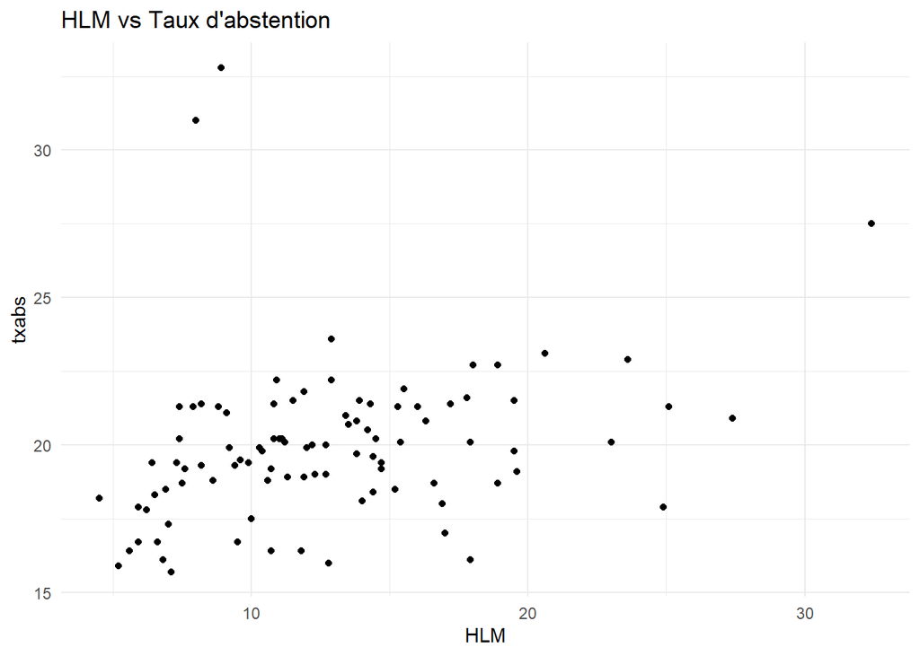

```r
ggplot(df, aes(x = HLM, y = txabs)) +
  geom_point() +
  theme_minimal() +
  labs(title = "HLM vs Taux d'abstention")
```

### Réduction de dimension (ACP)

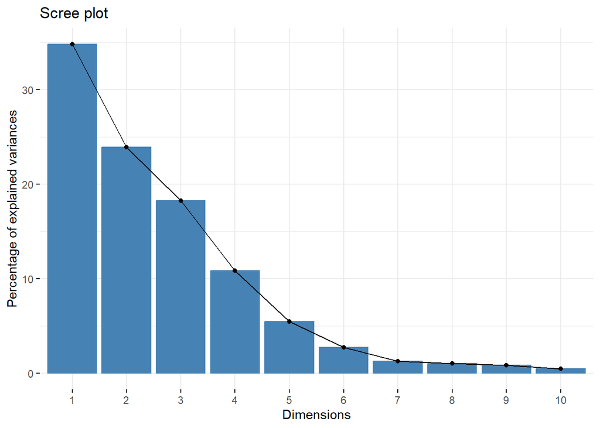

```r
library(compositions)
library(FactoMineR)
library(factoextra)

compositionnal_vars <- c("HLM", "Ouvrier", "Employe", "Cadres", "Artisant", "Agri")

data_clr <- clr(df_numeric[, compositionnal_vars])

other_vars <- df_numeric[, !colnames(df_numeric) %in% compositionnal_vars]


data_combined <- cbind(as.data.frame(data_clr), other_vars)


result_acp_combined <- PCA(data_combined, scale.unit = TRUE, ncp = 5, graph = FALSE)

fviz_screeplot(result_acp_combined)
```

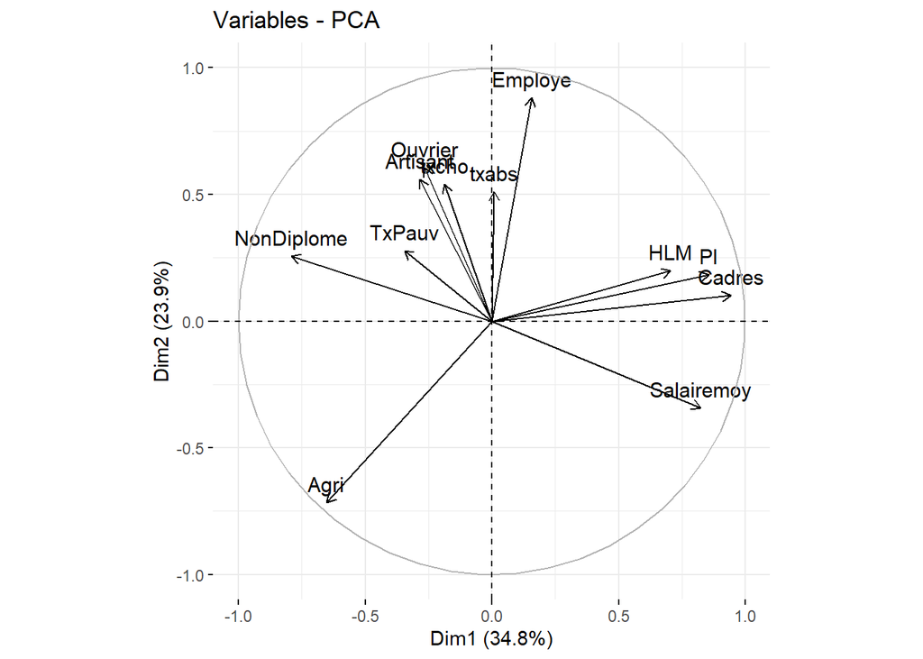

```r
fviz_pca_var(result_acp_combined)
```

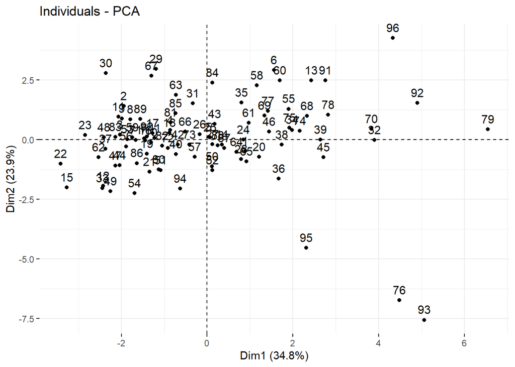

```r
fviz_pca_ind(result_acp_combined)
```

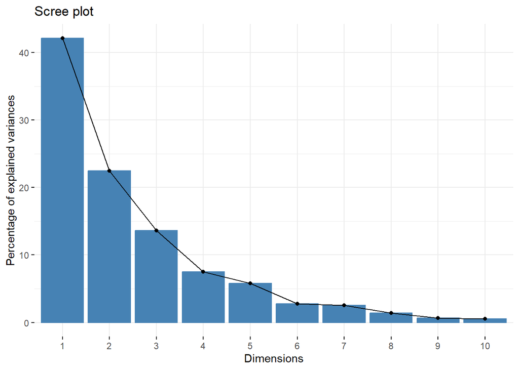

```r
data_acp <- scale(df_numeric)
result_acp <- PCA(as.data.frame(data_acp), scale.unit = TRUE, ncp = 5, graph = FALSE)

fviz_screeplot(result_acp)
```

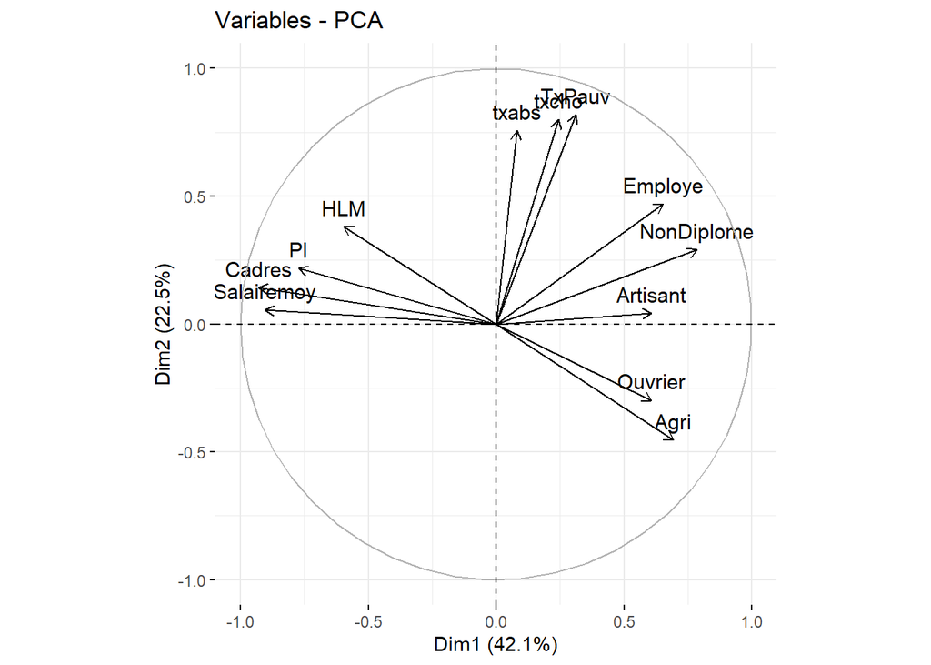

```r
fviz_pca_var(result_acp)
```

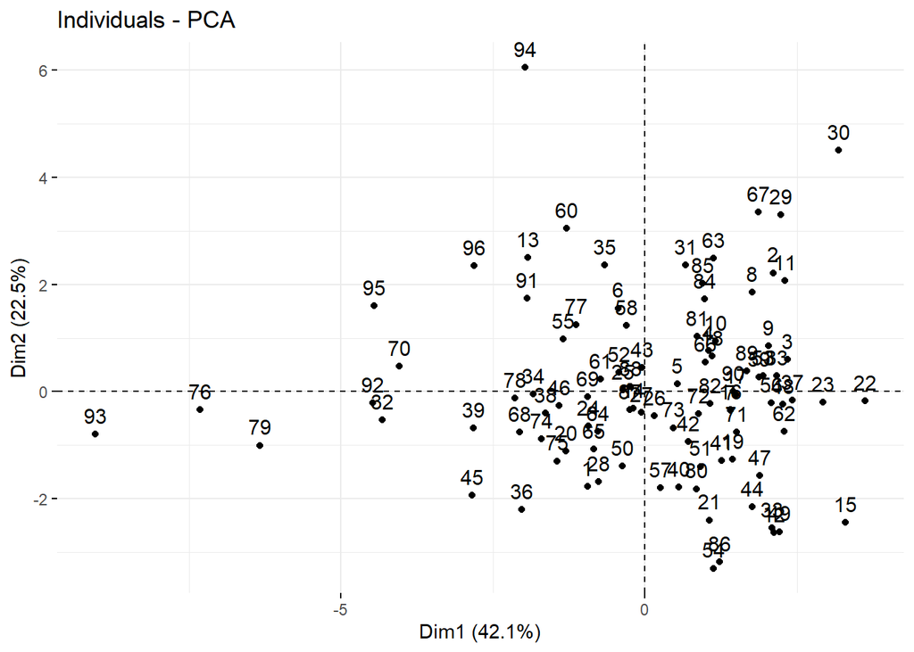

```r
fviz_pca_ind(result_acp)
```